# Mini project

Group 01: Aditya Samaroo & Yanqing Liu

01/03/2019

```r
library("data.table")
library("dplyr")
library("lubridate")
library("ggplot2")
library("gridExtra")
library("kableExtra")
library("pander")
library("stringr")
library("tm")
library("SnowballC")
library("wordcloud")
library("RColorBrewer")
```

```r
accidents <- read.csv("NYPD_Motor_Vehicle_Collisions.csv")
accidents = data.table(accidents) ## 1441945 lines
accidents = na.omit(accidents) ## 986984 lines
```

# World cloud for the first contribution factor of vehicle

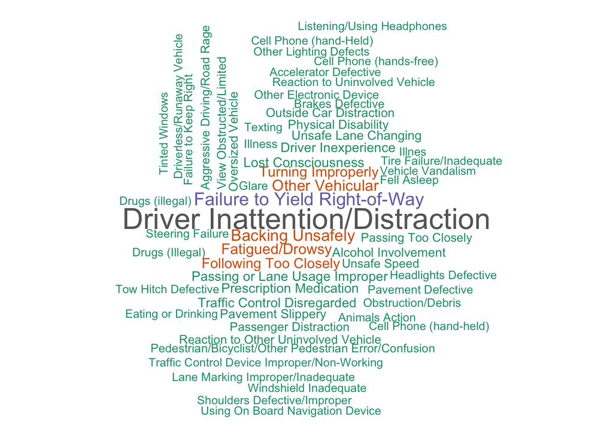

```r
data1 = accidents %>% filter(!CONTRIBUTING.FACTOR.VEHICLE.1 %in%
                               c("Unspecified", "1", "80", "", " "))
reason1 = data.frame(table(data1$CONTRIBUTING.FACTOR.VEHICLE.1))

wordcloud(words = reason1$Var1, freq = reason1$Freq#, type ="file"
          , scale = c(2,0.8), min.freq = 1
          , max.words = Inf, random.order = F, rot.per = 0.1
          , colors = brewer.pal(8, "Dark2"))
```

back to top

> Please note: Driver inattention or distraction is the most important factor to vehicle collisions. The second important factor is the Failure to Yield Right-of-way. Here, the size of word shows the importance.

# Trend of accidents by date

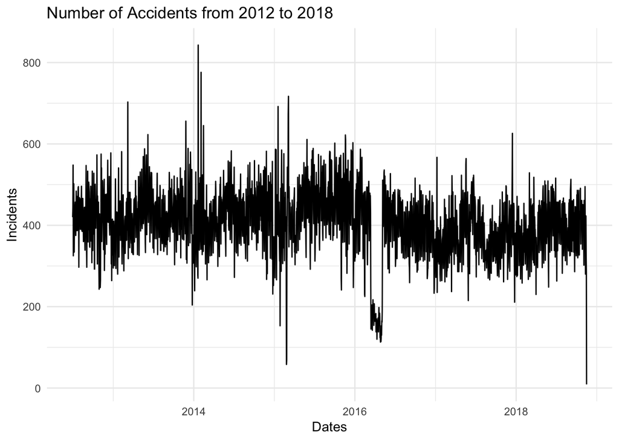

```r
counted <- accidents %>% group_by(DATE) %>% count(TIME)
counted <- counted %>% mutate(dates = as.Date(DATE, format = "%m/%d/%Y"))
counted_V2 <- counted %>% group_by(dates) %>% summarise(incidents = sum(n))
ggplot(counted_V2, aes(dates, incidents)) +
  geom_line() +
  theme_minimal() +
  xlab("Dates") + ylab("Incidents") +
  ggtitle("Number of Accidents from 2012 to 2018")
```

back to top

> Please note: Less accidents recent years than before, normally more accidents during the summer

# Relationship between type of vehicle and accident

## Using first vehicle code type and contribution factor 1

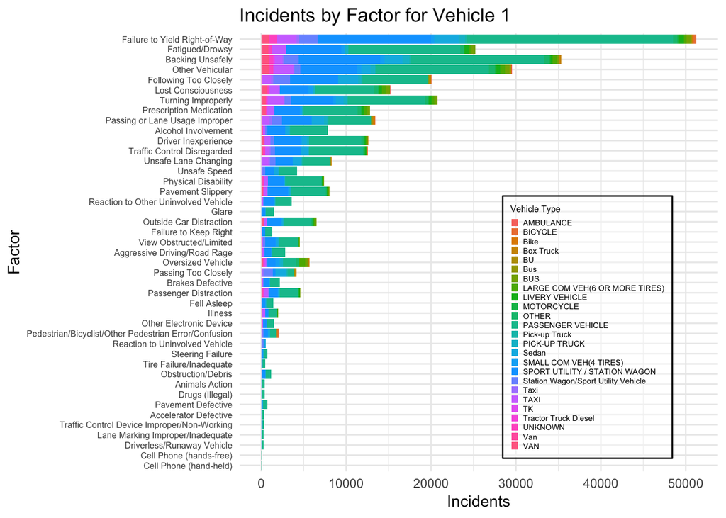

```r
type1 <- accidents %>% group_by(VEHICLE.TYPE.CODE.1) %>%
  count(CONTRIBUTING.FACTOR.VEHICLE.1) %>%
  arrange(desc(n))
type1[type1 == ""] <- NA
type1 <- na.omit(type1)
type1 <- data.frame(type1)
temp1 <- filter(type1, CONTRIBUTING.FACTOR.VEHICLE.1 != "Unspecified")
temp11 <- filter(type1,
                 CONTRIBUTING.FACTOR.VEHICLE.1 != "Driver Inattention/Distraction" &
                   CONTRIBUTING.FACTOR.VEHICLE.1 != "Unspecified" & n > 50)

p1 <- ggplot(temp11, aes(x = reorder(CONTRIBUTING.FACTOR.VEHICLE.1, n), y = n,
                         fill = VEHICLE.TYPE.CODE.1)) +
  geom_bar(stat = "identity") + theme_minimal() +
  theme(axis.text.y = element_text(size = 6),
        legend.key.width = unit(0.2,"cm"), legend.key.height=unit(0.2,"cm"),
        legend.position = c(.55, .03), legend.justification = c(0, 0),
        legend.background = element_rect(fill=alpha('white', 0.4)),
        legend.text = element_text(size = 5.5),
        legend.title = element_text(size = 6)) +
  xlab("Factor") + ylab("Incidents") +
  ggtitle("Incidents by Factor for Vehicle 1") +
  coord_flip() +
  guides(fill = guide_legend(ncol = 1, title = "Vehicle Type"))
p1
```

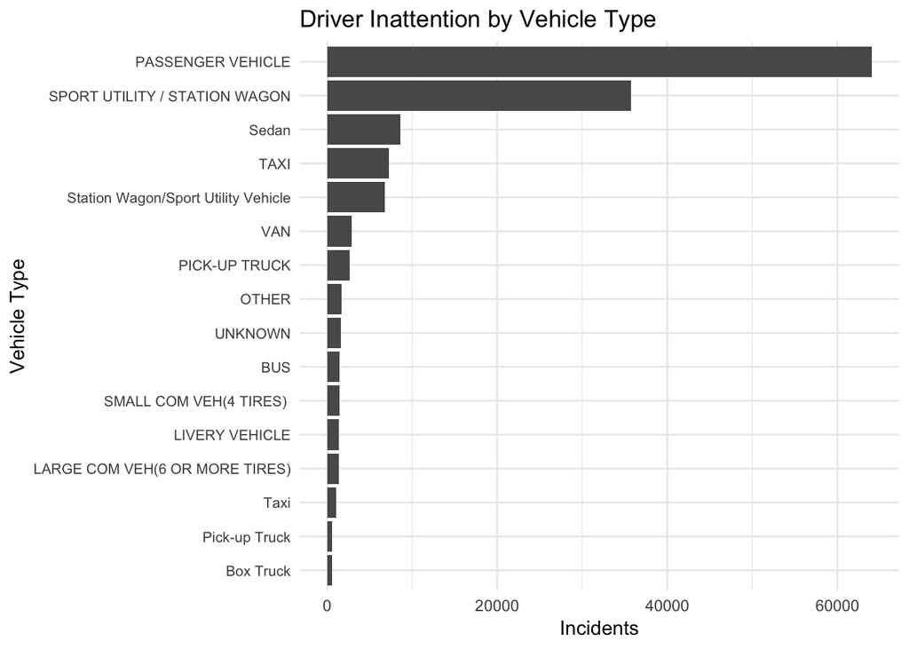

```r
temp111 <- filter(type1,
                  CONTRIBUTING.FACTOR.VEHICLE.1 == "Driver Inattention/Distraction",
                  n > 500)
p11 <- ggplot(temp111, aes(x = reorder(VEHICLE.TYPE.CODE.1, n), y = n)) +
  geom_bar(stat = "identity") + theme_minimal() +
  theme(axis.text.y = element_text(size = 8)) +
  xlab("Vehicle Type") + ylab("Incidents") +
  ggtitle("Driver Inattention by Vehicle Type") + coord_flip()
p11
```

back to top

> Passenger vehicle is the type of car who contribute the biggest volume in accidents, especially for driver inattention or distraction.

## Using second vehicle code type and contribution factor 2

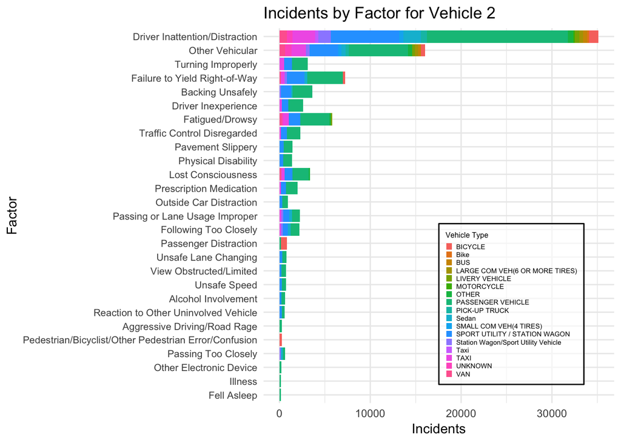

```r
type2 <- accidents %>% group_by(VEHICLE.TYPE.CODE.2) %>%
  count(CONTRIBUTING.FACTOR.VEHICLE.2) %>% arrange(desc(n))
type2[type2 == ""] <- NA
type2 <- na.omit(type2)
type2 <- data.frame(type2)
temp2 <- filter(type2, CONTRIBUTING.FACTOR.VEHICLE.2 != "Unspecified" & n > 150)

p2 <- ggplot(temp2, aes(x = reorder(CONTRIBUTING.FACTOR.VEHICLE.2,n), y = n,
                        fill = VEHICLE.TYPE.CODE.2)) +
  geom_bar(stat = "identity") + theme_minimal() +
  theme(axis.text.y = element_text(size = 8),
        legend.key.width = unit(0.2,"cm"), legend.key.height=unit(0.2,"cm"),
        legend.position = c(.5, .05), legend.justification = c(0, 0),
        legend.background = element_rect(fill=alpha('white', 0.6)),
        legend.text = element_text(size = 5.5),
        legend.title = element_text(size = 6)) +
  xlab("Factor") + ylab("Incidents") +
  ggtitle("Incidents by Factor for Vehicle 2") +
  coord_flip() +
  guides(fill = guide_legend(ncol = 1, title = "Vehicle Type"))
p2
```

back to top

## Using third vehicle code type and contributing factor 3

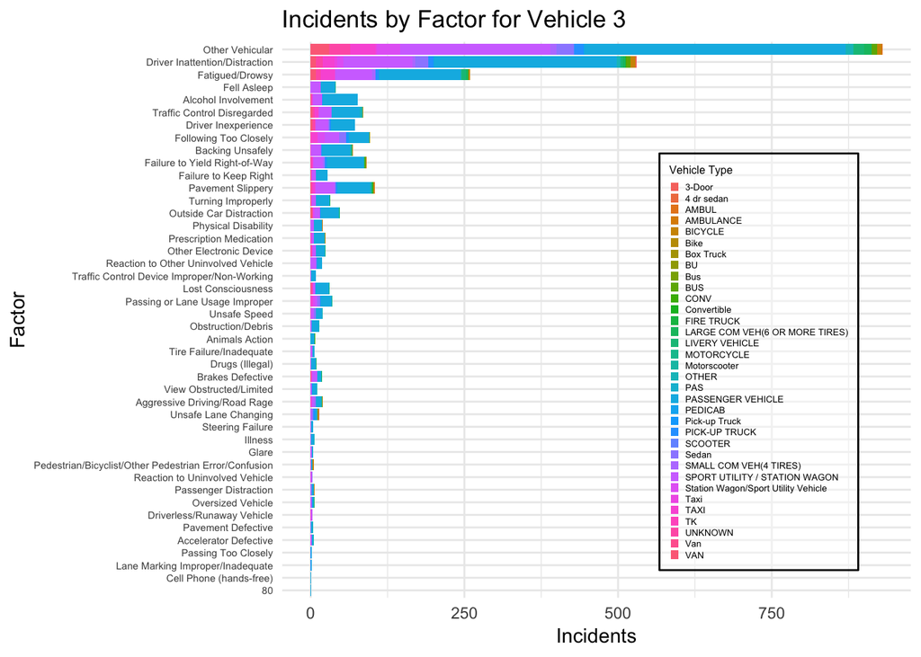

```r
type3 <- accidents %>% group_by(VEHICLE.TYPE.CODE.3) %>%
  count(CONTRIBUTING.FACTOR.VEHICLE.3) %>%
  arrange(desc(n))
type3[type3 == ""] <- NA
type3 <- na.omit(type3)
type3 <- data.frame(type3)
temp3 <- filter(type3, CONTRIBUTING.FACTOR.VEHICLE.3 != "Unspecified")

p3 <- ggplot(temp3, aes(x = reorder(CONTRIBUTING.FACTOR.VEHICLE.3,n), y = n,
                        fill = VEHICLE.TYPE.CODE.3)) +
  geom_bar(stat = "identity") + theme_minimal() +
  theme(axis.text.y = element_text(size = 5.5),
       legend.key.width = unit(0.2,"cm"), legend.key.height=unit(0.2,"cm") ,
       legend.position = c(0.6,.05), legend.justification = c(0, 0),
       legend.background = element_rect(fill=alpha('white', 0.4)),
       legend.text = element_text(size = 5),
       legend.title = element_text(size = 6)) +
  xlab("Factor") + ylab("Incidents") +
  ggtitle("Incidents by Factor for Vehicle 3") + coord_flip() +
  guides(fill = guide_legend(ncol = 1, title = "Vehicle Type"))
p3
```

back to top

> Past two vehicles, the third vehicle involved in the accident is usually caused by the other vehicles already involved

## Using fourth vehicle code type and contributing factor 4

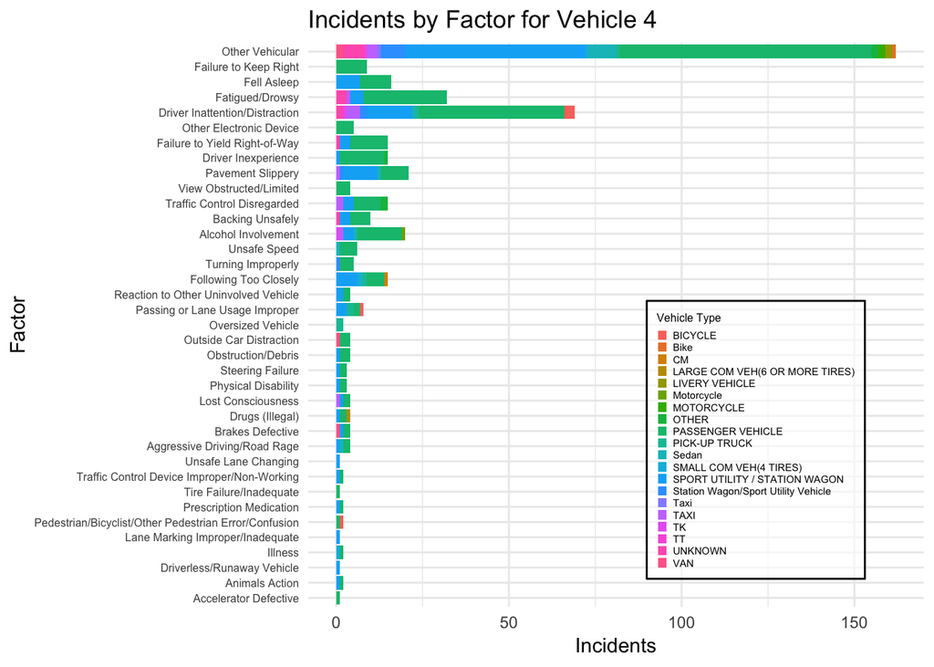

```r
type4 <- accidents %>% group_by(VEHICLE.TYPE.CODE.4) %>%
  count(CONTRIBUTING.FACTOR.VEHICLE.4) %>%  arrange(desc(n))
type4[type4 == ""] <- NA
type4 <- na.omit(type4)
type4 <- data.frame(type4)
temp4 <- filter(type4, CONTRIBUTING.FACTOR.VEHICLE.4 != "Unspecified")

p4 <- ggplot(temp4, aes(x = reorder(CONTRIBUTING.FACTOR.VEHICLE.4, n), y = n,
                        fill = VEHICLE.TYPE.CODE.4)) +
  geom_bar(stat = "identity") + theme_minimal() +
  theme(axis.text.y = element_text(size = 6),
        legend.key.width = unit(0.2,"cm"),
        legend.key.height = unit(0.2,"cm"),
        legend.position = c(.55, .05),
        legend.justification = c(0, 0),
        legend.background = element_rect(fill=alpha('white', 0.6)),
        legend.text = element_text(size = 5.5),
        legend.title = element_text(size = 6)) +
  xlab("Factor") + ylab("Incidents") + ggtitle("Incidents by Factor for Vehicle 4") +
  coord_flip() +
  guides(fill = guide_legend(ncol = 1, title = "Vehicle Type"))
p4
```

back to top

> Other vehicles are usually the cause for the fourth vehicle getting involved in an accident

## Using the last vehicle code type and contribution factor 5

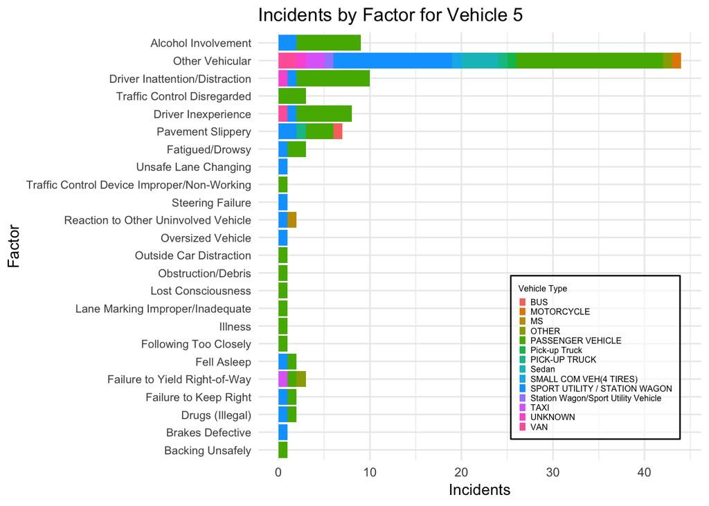

```r
type5 <- accidents %>% group_by(VEHICLE.TYPE.CODE.5) %>%
  count(CONTRIBUTING.FACTOR.VEHICLE.5) %>% arrange(desc(n))
type5[type5 == ""] <- NA
type5 <- na.omit(type5)
type5 <- data.frame(type5)
temp5 <- filter(type5, CONTRIBUTING.FACTOR.VEHICLE.5 != "Unspecified")

p5 <- ggplot(temp5, aes(x = reorder(CONTRIBUTING.FACTOR.VEHICLE.5,n), y = n,
                        fill = VEHICLE.TYPE.CODE.5)) +
  geom_bar(stat = "identity") + theme_minimal() +
  theme(axis.text.y = element_text(size = 8),
        legend.key.width = unit(0.2,"cm"),
        legend.key.height = unit(0.2,"cm"),
        legend.background = element_rect(fill=alpha('white', 0.6)),
        legend.position = c(.57, .05),
        legend.justification = c(0, 0),
        legend.text = element_text(size = 6),
        legend.title = element_text(size = 6)) +
  xlab("Factor") + ylab("Incidents") +
  ggtitle("Incidents by Factor for Vehicle 5") +
  coord_flip() +
  guides(fill = guide_legend(ncol = 1, title = "Vehicle Type"))
p5
```

back to top

# Relationship between time and borough for number of person injured

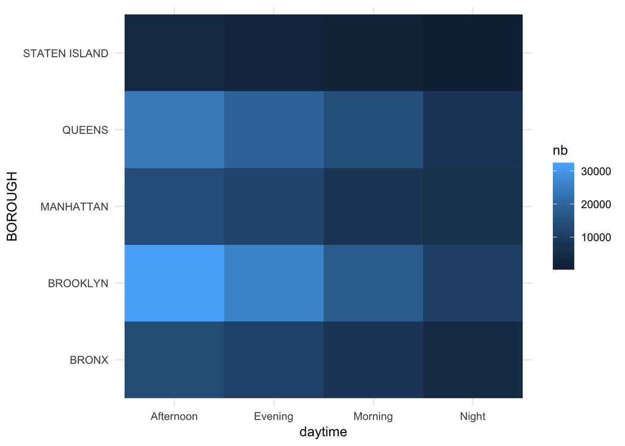

```r
accidents$hour = as.POSIXlt(as.POSIXlt(paste(Sys.Date(), accidents$TIME)))$hour
accidents$daytime = ifelse(accidents$hour >= 7 & accidents$hour < 12
                           , "Morning"
                           , ifelse(accidents$hour >= 12 & accidents$hour < 18
                                    , "Afternoon"
                                    , ifelse(accidents$hour >= 18 & accidents$hour < 24
                                             , "Evening"
                                             , "Night")))


accidents_daytime <- accidents %>% group_by(BOROUGH, daytime) %>% summarise(nb = sum(NUMBER.OF.PERSONS.INJURED, na.rm = TRUE))
ggplot(accidents_daytime, aes(x = daytime, y = BOROUGH, fill = nb)) + geom_tile() + theme_minimal()
```

back to top